# Stacked Ensemble Models for Classification of Conflicting Status of Variants

DA5030

Christopher-Courtney

2025-04-15

## Introduction:

The objective of this notebook is to analyze the [Genetic Variant Classifications](https://www.kaggle.com/datasets/kevinarvai/clinvar-conflicting) dataset, and build an ensemble ML model capable of accurately predicting conflicting clinical classifications of variants using a CRISP-DM approach.

[ClinVar](https://www.ncbi.nlm.nih.gov/clinvar/) is a public database widely used by the research and medical communities to study variant genes. User submissions are assigned a pathogenicity level ranging from benign to pathogenic. There are a large number of variables involved in this assignment, currently the majority of these are performed in the wet lab. A key problem is conflicting reports from different labs regarding the pathogenicity of the same variant.

The ability to identify genes with conflicting pathogenicity reports enables researchers to select genes for further characterization. Either to remove ambiguity regarding pathogenicity, or to exclude genes from disease focused studies until more data clarifying their role hs been presented.

A detailed explanation of much of the features in this dataset can be found [here](https://www.ncbi.nlm.nih.gov/clinvar/docs/help/) Though it should be noted some of the column names are different, they contain the correct data.

## EDA:

The first step is observing the general structure of the dataset.

```r
str(df)
```

```
## 'data.frame':    65188 obs. of  46 variables:
##  $ CHROM             : Factor w/ 24 levels "1","10","11",..: 1 1 1 1 1 1 1 1 1 1 ...
##  $ POS               : int  1168180 1470752 1737942 2160305 2160305 2160554 3328358 3328659 3347452 5925304 ...
##  $ REF               : Factor w/ 866 levels "A","AA","AAAAAAAAACAAAAAAAAAAAC",..: 438 438 1 438 438 438 645 225 438 438 ...
##  $ ALT               : Factor w/ 458 levels "A","AA","AAAA",..: 107 1 214 1 336 107 107 336 1 1 ...
##  $ AF_ESP            : num  0.0771 0 0 0 0 ...
##  $ AF_EXAC           : num  1e-01 0e+00 1e-05 0e+00 0e+00 ...
##  $ AF_TGP            : num  0.107 0 0 0 0 ...
##  $ CLNDISDB          : Factor w/ 9234 levels ".|.|.|.|.|.|MedGen:C0002312,OMIM:604131,Orphanet:ORPHA846,SNOMED_CT:68913001|MedGen:CN169374",..: 8505 6254 751 5632 5628 5632 8505 8505 8060 5217 ...
##  $ CLNDISDBINCL      : Factor w/ 94 levels ".",".|.",".|.|.",..: 94 94 94 94 94 94 94 94 94 94 ...
##  $ CLNDN             : Factor w/ 9260 levels "2-aminoadipic_2-oxoadipic_aciduria|not_specified|not_provided",..: 6794 8703 8765 8469 8468 8469 6794 6794 5043 6556 ...
##  $ CLNDNINCL         : Factor w/ 102 levels "2-aminoadipic_2-oxoadipic_aciduria",..: 81 81 81 81 81 81 81 81 81 81 ...
##  $ CLNHGVS           : Factor w/ 65188 levels "NC_000001.10:g.100316589A>G",..: 327 468 1180 1827 1828 1847 3070 3074 3100 3932 ...
##  $ CLNSIGINCL        : Factor w/ 138 levels "10361:Pathogenic|10382:other",..: 138 138 138 138 138 138 138 138 138 138 ...
##  $ CLNVC             : Factor w/ 7 levels "Deletion","Duplication",..: 7 7 7 7 7 7 7 7 7 7 ...
```

[output cut: 32 more lines]

The data consists of 65188 observations with a mixture of 46 categorical and continuous features. The target feature CLASS is a binary feature with 0 indicating consensus on pathogenic status of a variant and 1 indicating conflict.

There are multiple columns that appear to be unique identifiers or filled with NA values. Several need to be relabeled as factors. CLNHGVS, and POS are unique identifiers and will be dropped during handling of NA.

```r
summary(df)
```

```
##      CHROM            POS                 REF             ALT
##  2      : 8645   Min.   :      961   C      :21798   T      :20409
##  17     : 5394   1st Qu.: 32541793   G      :21361   A      :20205
##  11     : 4846   Median : 57970213   A      : 9845   G      :11782
##  1      : 4454   Mean   : 77575939   T      : 9421   C      :11429
##  16     : 3927   3rd Qu.:112745411   CT     :  126   TA     :  118
##  19     : 3911   Max.   :247607973   GC     :  113   CT     :   93
##  (Other):34011                       (Other): 2524   (Other): 1152
##      AF_ESP           AF_EXAC            AF_TGP
##  Min.   :0.00000   Min.   :0.00000   Min.   :0.00000
##  1st Qu.:0.00000   1st Qu.:0.00000   1st Qu.:0.00000
##  Median :0.00000   Median :0.00004   Median :0.00000
##  Mean   :0.01451   Mean   :0.01449   Mean   :0.01526
##  3rd Qu.:0.00120   3rd Qu.:0.00123   3rd Qu.:0.00160
##  Max.   :0.49900   Max.   :0.49989   Max.   :0.49980
##
##                                                                                          CLNDISDB
##  MedGen:CN169374                                                                             : 5344
##  MedGen:C0027672,SNOMED_CT:699346009|MedGen:CN169374                                         : 1724
##  MedGen:CN169374|MedGen:CN517202                                                             : 1398
##  MedGen:C0027672,SNOMED_CT:699346009                                                         : 1139
##  MedGen:C1837342,OMIM:608807,Orphanet:ORPHA140922|MedGen:C1858763,OMIM:604145|MedGen:CN169374:  913
##  MedGen:C0020445,OMIM:143890,SNOMED_CT:397915002,SNOMED_CT:398036000                         :  732
##  (Other)                                                                                     :53938
##                                                               CLNDISDBINCL
##  nan                                                                :65021
##  .                                                                  :   11
##  MedGen:CN169374                                                    :   11
##  MedGen:C0220754,OMIM:253260,Orphanet:ORPHA79241,SNOMED_CT:8808004  :    8
##  MedGen:C0020445,OMIM:143890,SNOMED_CT:397915002,SNOMED_CT:398036000:    6
##  MeSH:C535804,MedGen:C1855465,OMIM:248200                           :    6
##  (Other)                                                            :  125
##                                                                              CLNDN
##  not_specified                                                                  : 5344
##  Hereditary_cancer-predisposing_syndrome|not_specified                          : 1724
##  not_specified|not_provided                                                     : 1398
##  Hereditary_cancer-predisposing_syndrome                                        : 1139
##  Limb-girdle_muscular_dystrophy,_type_2J|Dilated_cardiomyopathy_1G|not_specified:  913
##  Familial_hypercholesterolemia                                                  :  732
##  (Other)                                                                        :53938
```

[output cut: 89 more lines]

```
##                :65186   Min.   :1        :65186      Min.   :-0.10
##  Egr1:MA0341.1 :    1   1st Qu.:1       N:    2      1st Qu.:-0.09
##  FOXA1:MA0546.1:    1   Median :1                    Median :-0.08
##                         Mean   :1                    Mean   :-0.08
##                         3rd Qu.:1                    3rd Qu.:-0.07
##                         Max.   :1                    Max.   :-0.06
##                         NA's   :65186                NA's   :65186
##     LoFtool        CADD_PHRED        CADD_RAW      BLOSUM62
##  Min.   :0.000   Min.   : 0.001   Min.   :-5.477   -3  : 4450
##  1st Qu.:0.024   1st Qu.: 7.141   1st Qu.: 0.463   -2  : 4300
##  Median :0.157   Median :14.090   Median : 1.643   -1  : 5336
##  Mean   :0.345   Mean   :15.686   Mean   : 2.554   1   : 7696
##  3rd Qu.:0.710   3rd Qu.:24.100   3rd Qu.: 4.381   2   : 2138
##  Max.   :1.000   Max.   :99.000   Max.   :46.556   3   : 1673
##  NA's   :4213    NA's   :1092     NA's   :1092     NA's:39595
```

Multiple features have NA values or consist largely thereof. These will be imputed or dropped on a case by case basis. Several features have high cardinality, and will be simplified or dropped.

Before progressing an overview of CLASS distribution will be useful.

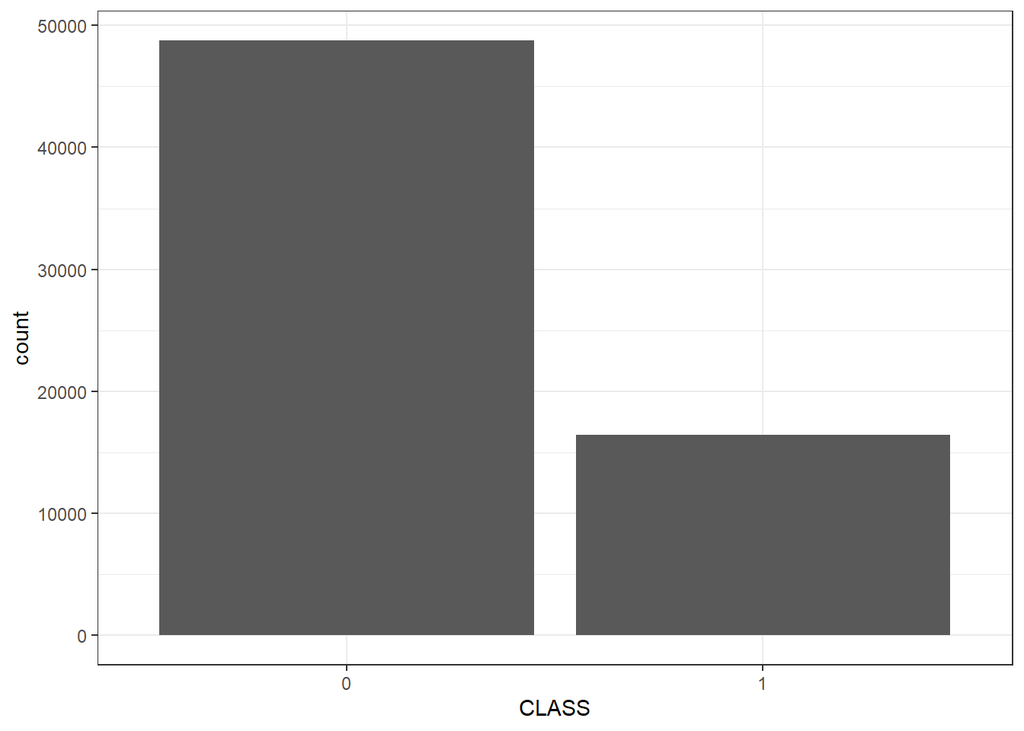

There is clearly a class imbalance, largely in favor of 0 or “no conflict”. This will be addressed using a combination of up and down sampling.

### EDA: NA and Outlier Handling

Before performing a more in depth analysis of features NA values will be dropped. Several features have either nan, ““, or NA for over half of their entries. These will be dropped completely. Note that Intron is mostly NA because of the large number of variants located within exons. This information will be captured using other methods.

```r
# get NA columns
na.features <- c("CLNDISDBINCL", "CLNDNINCL", "CLNSIGINCL", "CLNVI", "SSR",
                 "INTRON", "MOTIF_NAME", "MOTIF_POS", "HIGH_INF_POS",
                 "MOTIF_SCORE_CHANGE", "DISTANCE", "BAM_EDIT", "CLNHGVS", "POS")

# Remove NA columns
df.clean <- df %>% select(-all_of(na.features))

# verify
ncol(df.clean)
```

```
## [1] 32
```

```r
summary(df.clean)
```

```
##      CHROM            REF             ALT            AF_ESP
##  2      : 8645   C      :21798   T      :20409   Min.   :0.00000
##  17     : 5394   G      :21361   A      :20205   1st Qu.:0.00000
##  11     : 4846   A      : 9845   G      :11782   Median :0.00000
##  1      : 4454   T      : 9421   C      :11429   Mean   :0.01451
##  16     : 3927   CT     :  126   TA     :  118   3rd Qu.:0.00120
##  19     : 3911   GC     :  113   CT     :   93   Max.   :0.49900
##  (Other):34011   (Other): 2524   (Other): 1152
##     AF_EXAC            AF_TGP
##  Min.   :0.00000   Min.   :0.00000
##  1st Qu.:0.00000   1st Qu.:0.00000
##  Median :0.00004   Median :0.00000
##  Mean   :0.01449   Mean   :0.01526
##  3rd Qu.:0.00123   3rd Qu.:0.00160
##  Max.   :0.49989   Max.   :0.49980
##
##                                                                                          CLNDISDB
##  MedGen:CN169374                                                                             : 5344
##  MedGen:C0027672,SNOMED_CT:699346009|MedGen:CN169374                                         : 1724
##  MedGen:CN169374|MedGen:CN517202                                                             : 1398
##  MedGen:C0027672,SNOMED_CT:699346009                                                         : 1139
##  MedGen:C1837342,OMIM:608807,Orphanet:ORPHA140922|MedGen:C1858763,OMIM:604145|MedGen:CN169374:  913
##  MedGen:C0020445,OMIM:143890,SNOMED_CT:397915002,SNOMED_CT:398036000                         :  732
##  (Other)                                                                                     :53938
##                                                                              CLNDN
##  not_specified                                                                  : 5344
##  Hereditary_cancer-predisposing_syndrome|not_specified                          : 1724
##  not_specified|not_provided                                                     : 1398
##  Hereditary_cancer-predisposing_syndrome                                        : 1139
##  Limb-girdle_muscular_dystrophy,_type_2J|Dilated_cardiomyopathy_1G|not_specified:  913
##  Familial_hypercholesterolemia                                                  :  732
##  (Other)                                                                        :53938
##                        CLNVC
##  Deletion                 : 2509
##  Duplication              : 1034
##  Indel                    :  247
##  Insertion                :   95
##  Inversion                :   17
##  Microsatellite           :    5
##  single_nucleotide_variant:61281
```

[output cut: 41 more lines]

```
##                            :40352                    :40392   Min.   :0.000
##  deleterious               :11500   benign           :13329   1st Qu.:0.024
##  deleterious_low_confidence:  775   possibly_damaging: 3932   Median :0.157
##  tolerated                 :11484   probably_damaging: 7531   Mean   :0.345
##  tolerated_low_confidence  : 1077   unknown          :    4   3rd Qu.:0.710
##                                                               Max.   :1.000
##                                                               NA's   :4213
##    CADD_PHRED        CADD_RAW      BLOSUM62
##  Min.   : 0.001   Min.   :-5.477   -3  : 4450
##  1st Qu.: 7.141   1st Qu.: 0.463   -2  : 4300
##  Median :14.090   Median : 1.643   -1  : 5336
##  Mean   :15.686   Mean   : 2.554   1   : 7696
##  3rd Qu.:24.100   3rd Qu.: 4.381   2   : 2138
##  Max.   :99.000   Max.   :46.556   3   : 1673
##  NA's   :1092     NA's   :1092     NA's:39595
```

Features such as SIFT and PolyPhen may have predictive power, however it will require a relabel of the missing data and a check of the target variable’s distribution downstream.

This is shown in the table below, note entries now contain “missing”.

```
## 'data.frame':    65188 obs. of  5 variables:
##  $ SIFT        : Factor w/ 5 levels "deleterious",..: 4 2 1 3 3 3 3 3 3 1 ...
##  $ PolyPhen    : Factor w/ 5 levels "benign","missing",..: 1 1 4 2 2 2 2 2 2 1 ...
##  $ BLOSUM62    : Factor w/ 7 levels "1","2","3","4",..: 5 1 3 7 1 2 3 1 4 3 ...
##  $ Feature_type: Factor w/ 3 levels "missing","MotifFeature",..: 3 3 3 3 3 3 3 3 3 3 ...
##  $ BIOTYPE     : Factor w/ 3 levels "misc_RNA","missing",..: 3 3 3 3 3 3 3 3 3 3 ...
```

### EDA: Remaining NA

Remaining NA values will be identified for imputation. It should be noted that several columns have essentially NA values. CLNDN has several entries that equate to NA, but as the very absence of this information may be significant they will be collapsed into one class for further feature engineering downstream.

EXON, cDNA_position, CDS_position, Protein_position, Amino_acids, an Codons all have empty strings in similar quantities indicating a pattern, and confirmed by the fact that they are all associated with non-coding assignments in the Consequence column. This is highlighted in the table below.

|  | CLASS | Consequence | EXON | cDNA_position | CDS_position | Protein_position | Amino_acids | Codons |
| --- | --- | --- | --- | --- | --- | --- | --- | --- |
| 1227 | 1 | intron_variant |  |  |  |  |  |  |
| 1228 | 1 | intron_variant |  |  |  |  |  |  |
| 1229 | 1 | intron_variant |  |  |  |  |  |  |
| 1230 | 0 | intron_variant |  |  |  |  |  |  |
| 1231 | 1 | intron_variant |  |  |  |  |  |  |
| 1232 | 1 | intron_variant |  |  |  |  |  |  |

The empty values for the positional columns will be replaced with a non_coding indicator to preserve biological context.

|  | CLASS | Consequence | EXON | cDNA_position | CDS_position | Protein_position | Amino_acids | Codons |
| --- | --- | --- | --- | --- | --- | --- | --- | --- |
| 1227 | 1 | intron_variant | non_coding | non_coding | non_coding | non_coding | non_coding | non_coding |
| 1228 | 1 | intron_variant | non_coding | non_coding | non_coding | non_coding | non_coding | non_coding |
| 1229 | 1 | intron_variant | non_coding | non_coding | non_coding | non_coding | non_coding | non_coding |
| 1230 | 0 | intron_variant | non_coding | non_coding | non_coding | non_coding | non_coding | non_coding |
| 1231 | 1 | intron_variant | non_coding | non_coding | non_coding | non_coding | non_coding | non_coding |
| 1232 | 1 | intron_variant | non_coding | non_coding | non_coding | non_coding | non_coding | non_coding |

All NA values have been handled at this point with the exception of true NA values within otherwise informative columns.

```
##            CHROM              REF              ALT           AF_ESP
##                0                0                0                0
##          AF_EXAC           AF_TGP         CLNDISDB            CLNDN
##                0                0                0                0
##            CLNVC               MC           ORIGIN            CLASS
##                0                0                0                0
##           Allele      Consequence           IMPACT           SYMBOL
##                0                0                0                0
##     Feature_type          Feature          BIOTYPE             EXON
##                0                0                0                0
##    cDNA_position     CDS_position Protein_position      Amino_acids
##                0                0                0                0
##           Codons           STRAND             SIFT         PolyPhen
##                0               14                0                0
##          LoFtool       CADD_PHRED         CADD_RAW         BLOSUM62
##             4213             1092             1092                0
```

STRAND has only a small amount of NA values, they will simply be dropped.

A final check will be made to sensure NA values have been removed.

```
##            CHROM              REF              ALT           AF_ESP
##                0                0                0                0
##          AF_EXAC           AF_TGP         CLNDISDB            CLNDN
##                0                0                0                0
##            CLNVC               MC           ORIGIN            CLASS
##                0                0                0                0
##           Allele      Consequence           IMPACT           SYMBOL
##                0                0                0                0
##     Feature_type          Feature          BIOTYPE             EXON
##                0                0                0                0
##    cDNA_position     CDS_position Protein_position      Amino_acids
##                0                0                0                0
##           Codons           STRAND             SIFT         PolyPhen
##                0                0                0                0
##          LoFtool       CADD_PHRED         CADD_RAW         BLOSUM62
##                0                0                0                0
```

No NA found.

### EDA: Handling Outliers

Outliers in continuous variables will be identified and removed, using a z.score greater than 3.0 as the threshold.

```
##   CLASS AF_ESP AF_EXAC AF_TGP LoFtool CADD_PHRED  CADD_RAW z.AF_ESP  z.AF_EXAC
## 1     0 0.2806 0.19344 0.2995  0.3780     12.950  1.430808 4.603473  3.0050442
## 2     0 0.2700 0.29739 0.3005  0.7880     14.400  1.698720 4.420085  4.7506915
## 3     0 0.1588 0.17910 0.2670  0.0447      8.375  0.631890 2.496251  2.7642306
## 4     0 0.2682 0.27912 0.2113  0.8690     12.550  1.354598 4.388944  4.4438808
## 5     0 0.4693 0.00000 0.4349  0.6990      0.013 -1.041735 7.868109 -0.2434215
## 6     0 0.2781 0.30335 0.3974  0.0969      4.598  0.192360 4.560221  4.8507786
##   z.AF_TGP   z.LoFtool z.CADD_PHRED z.CADD_RAW
## 1 4.774351  0.09701373   -0.2657284 -0.3913961
## 2 4.791148  1.25966311   -0.1326388 -0.3018443
## 3 4.228438 -0.84813515   -0.6856491 -0.6584412
## 4 3.292829  1.48935725   -0.3024428 -0.4168700
## 5 7.048705  1.00728312   -1.4531632 -1.2178645
## 6 6.418806 -0.70011003   -1.0323246 -0.8053578
```

There are over 3468 outliers. They will be imputed via kNN using the same process that was applied to NA values.

### EDA: MultiColinearity Assesment

Decision Trees, Random Forest, and to a certain extent logistic regression with elastic net can be resistant to multicolinearity naturally, to optimize the models and minimize variance it is still reasonable to identify any potential multicolinearity.

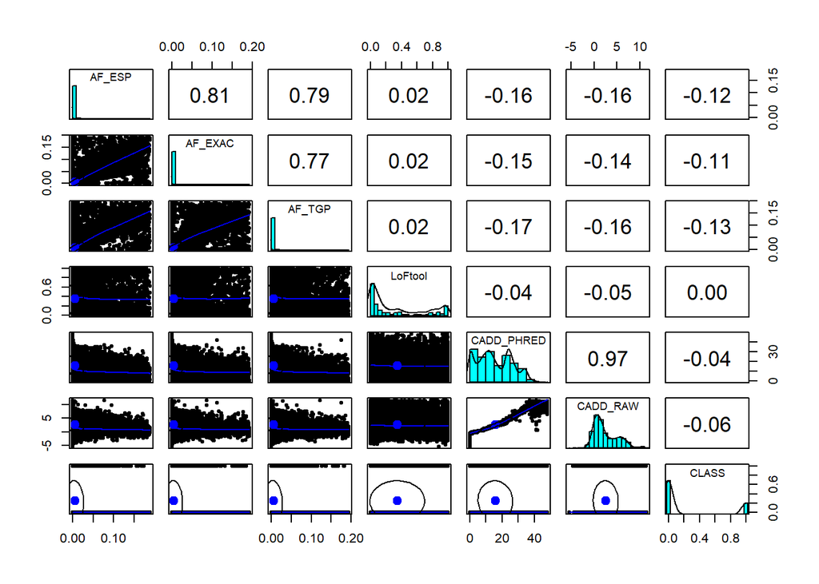

It appears that AF_ESP, AF_EXAC, and AF_TGP are all strongly correlated, this is reasonable as they are all allele frequency metrics.

Several categorical variables appear to be closely related based on previous analysis.

They include, CLNDISDB, and CLNDN, which are codes representing various diseases, and a human readable version respectively.

SYMBOL and Feature, where feature contains a code for a transcription factor for a particular gene are also closely related.

cDNA_position, CDS_position, and Protein_position are also highly correlated based on biological context alone.

For the decision tree and randomforest models these will be retained, as these models are generally resistant to multicollinearity and in fact they performed *worse* when removed during testing.

The logistic regression model with elastic net being implemented is arguably more susceptible to multicollinearity, however downstream testing showed that the model performed poorly when it was performed. This will be shown downstream.

### EDA: Feature by Feature Investigation

A more in depth investigation of each feature will be conducted to better perform feature engineering and encoding.

### EDA: Continuous Features

AF_XXX features and CADD_XXX scores will be shown for one variable each, their distributions are extremely similar.

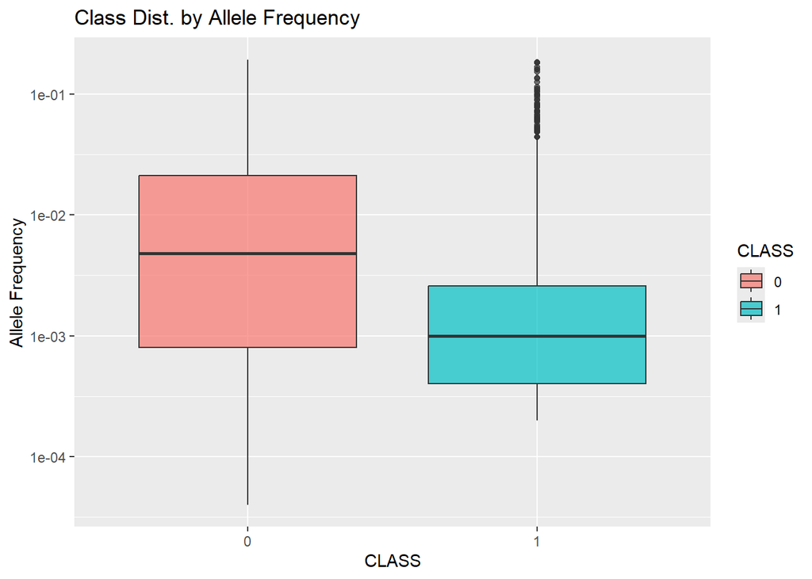

Distribution shows that allele frequency is notably lower, this is reasonable given that rarer alleles are typically harder to study.

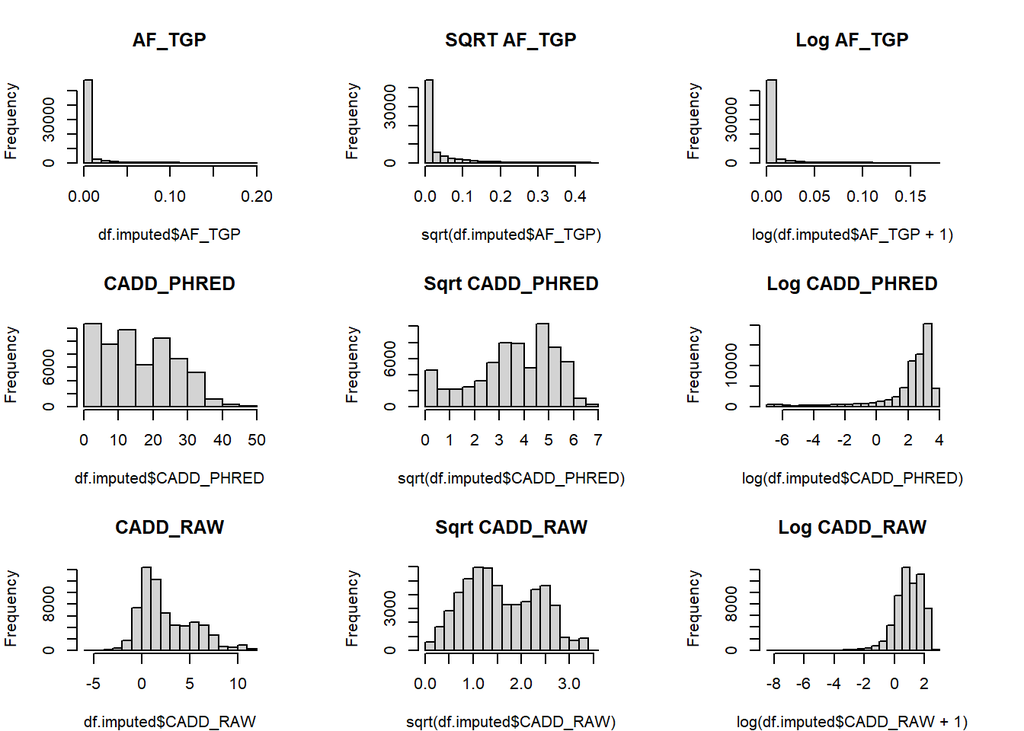

It should be noted that while transformation of AF_TGP showed a marginaly better distribution, this transformation did not translate into an improvement in model performance and was not retained. This sentiment was similar for all continuous features.

Finally, transforms of CADD scores do show some potential but yielded poor results. this will be shown downstream.

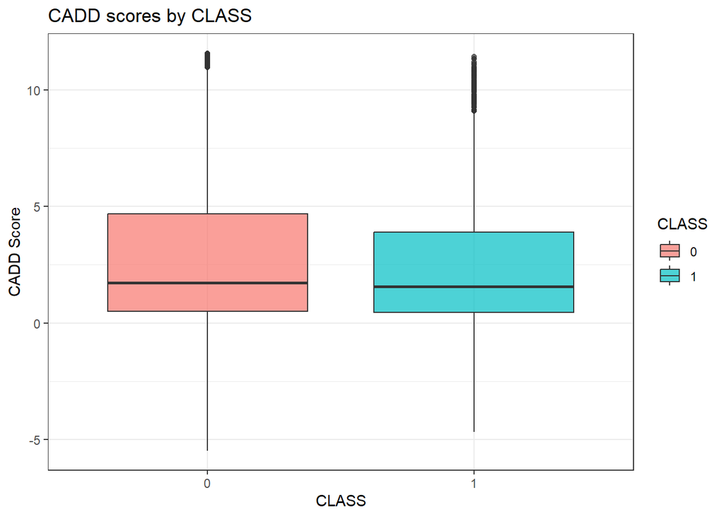

CADD scores show similar distribution across CLASS, though conflicting variants may have slightly lower scores.

### EDA:“Low” cardinality Features

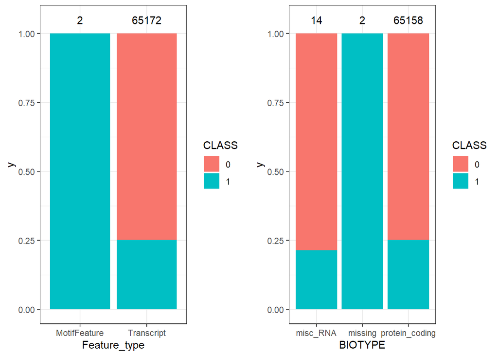

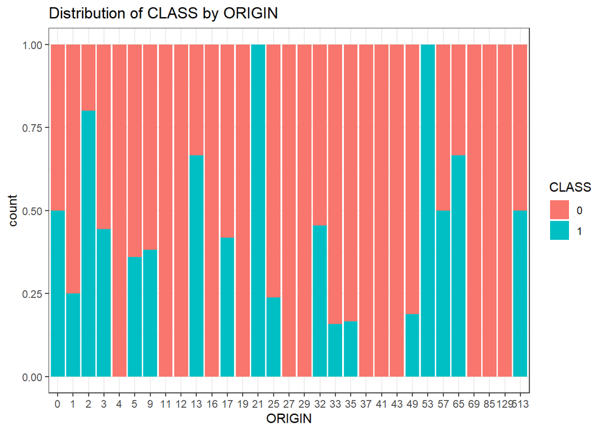

ORIGIN indicates the source of the variant using bit notation. The table below shows there are several entries that have only a few data points. This can be converted to a binary column indicating if it is classified as 1 or something else.

```
##
##     0     1     2     3     4     5     9    11    12    13    16    17    19
##    13 63929     5   269     3   200   144     1     1     3     2   188     1
##    21    25    27    29    32    33    35    37    41    43    49    53    57
##     3    21     1     1    11   330     6     2     5     1    16     1     2
##    65    69    85   129   513
##     6     1     1     1     6
```

The table above shows counts for individual ORIGIN scores, supporting conversion to a dummy coded feature.

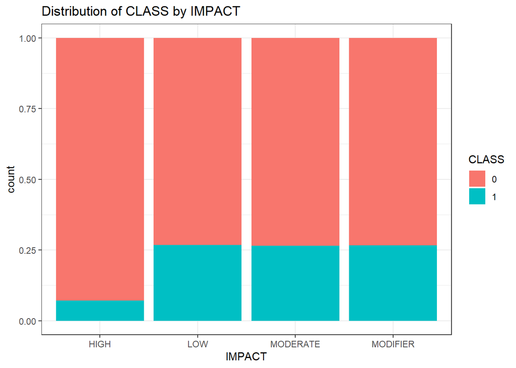

It appears that if a variant is High impact, there is less likely to be contention about a variant’s classification. In this case a simply dummy encoding a “HIGH” indicator will be sufficient.

CHROM and CLNV are compared below.

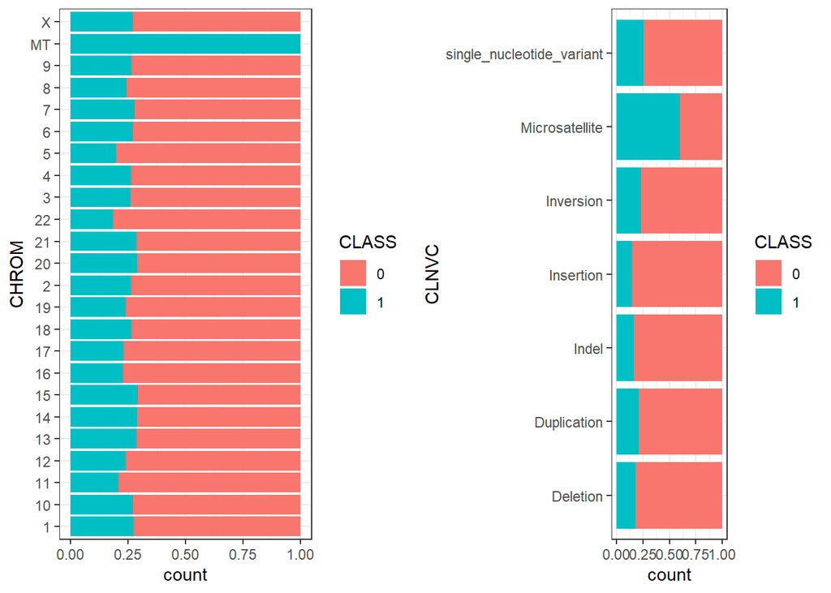

There is some variation in CLASS distribution across each Chromosome with a notable increase in uncertainty in mitochondrial DNA, of course there are only a few observations as seen in the table below. Weight of Evidence (WOE) encoding will be applied here due to cardnality.

```
##
##    1   10   11   12   13   14   15   16   17   18   19    2   20   21   22    3
## 4454 2341 4846 2750 2646 1974 1725 3927 5394  896 3911 8645  759  843 1135 2529
##    4    5    6    7    8    9   MT    X
## 1206 3643 2159 2867 1852 2744    2 1926
```

CLNVC shares a similarities to CHROM, with Microsatellite variants being more likely to have contention. WOE will be applied here as well.

SIFT, PolyPhen, and BLOSUM62 contain large amounts of missing values, however they also contain information regarding a variant’s pathogenicity and deviation from the original sequence. A more in depth look is warranted.

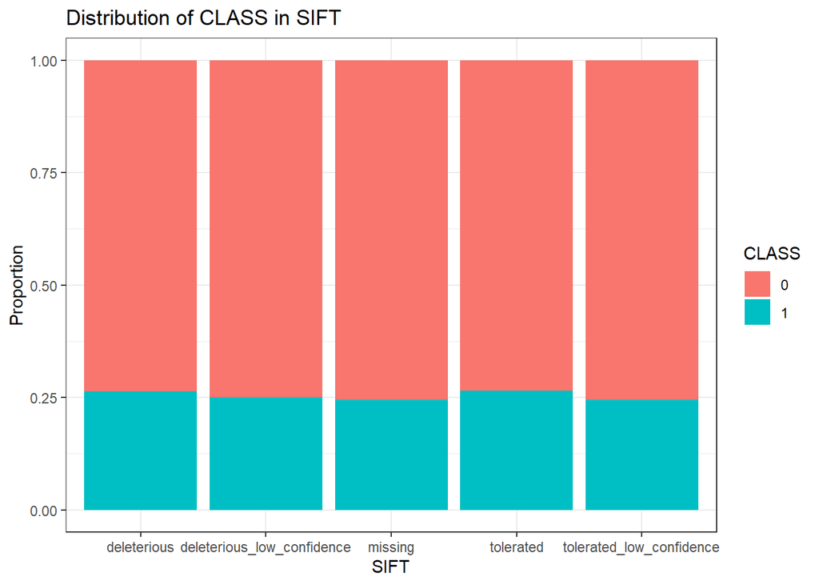

There is very little variation in the distribution of CLASS across categories, while is likely not individually predictive, theres a strong possibility it has signal when combined with other features. This feature will undergo WOE encoding with the high-cardinality variables.

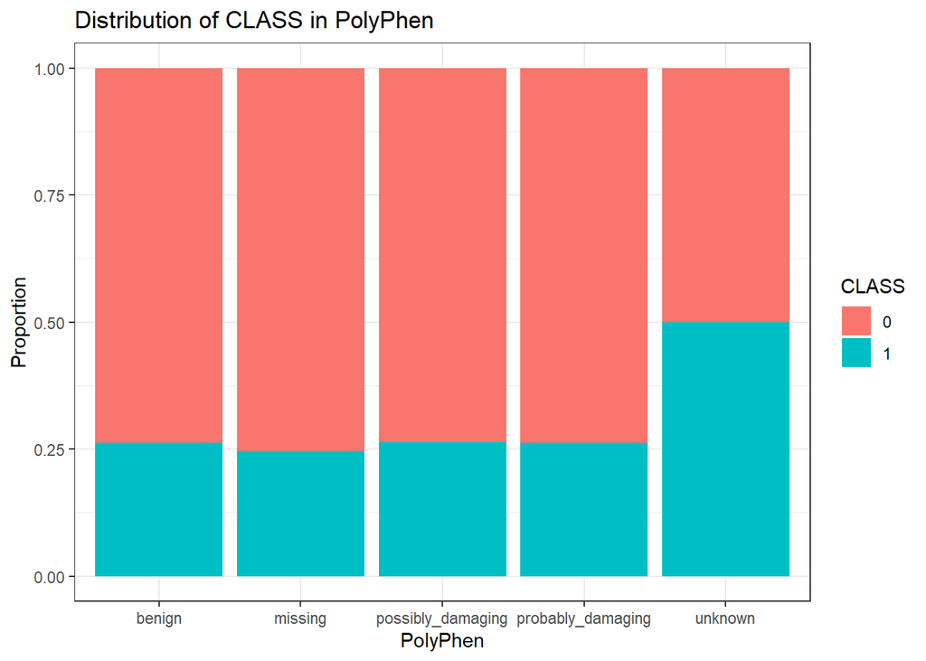

PolyPhen has slight variation around each category, while there are only 4 entries for the unknown category, half are positive for conflicted status. WOE encoding will be applied.

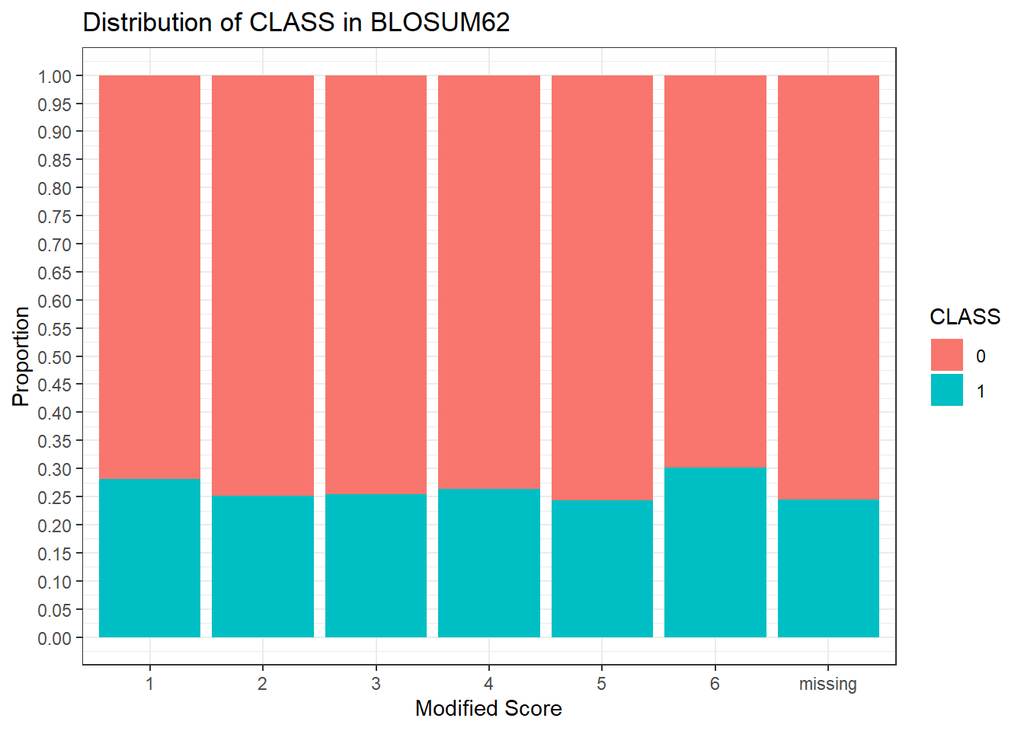

### EDA: High Cardinality Features.

Recall from the summary call that the REF and ALT features. In their current state they do not provide data useful to a machine learning mode, but they do contain quite a bit of useful information.

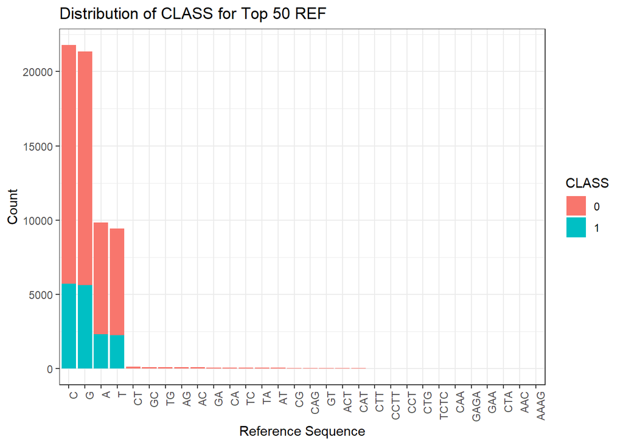

From these features we can discern a few things. Whether the variant is a Single nucleotide variant, insertion, deletion, the change in length of the variant, and whether or not the SNVs were transitions or transversions.

Based on an analysis performed [here](https://www.kaggle.com/code/vasilyb/clinvar-identifying-conflicting-genetic-variants#2.-DATA-TRANSFORMATION) and some experimentation not shown. A binary SNV column will be added, and the lengths of reference,alt,and allele, be added as columns.

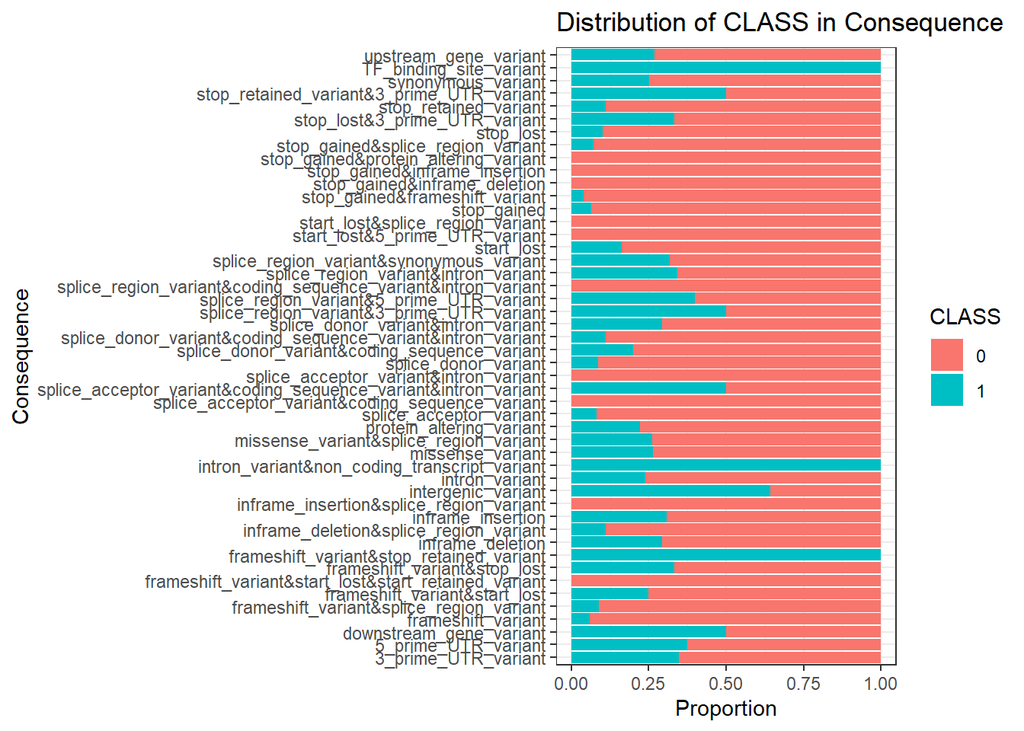

Consequence and MC have several levels with low frequency that are unique combinations of individual levels and the same name, in this case one-hot encoding the data with binary columns for individual levels will decrease the overall complexity of the data and make it more interpretable to ML models by allowing them to capture obervations consistently marked with several variables.

The Chart below shows a distribution of the positive CLASS by gene SYMBOL, it is an adaptation of one found [here](https://www.kaggle.com/code/kevinarvai/genetic-variant-classifications-eda) and was implemented to highlight the importance of one of the high cardinality features.

It should be noted that there are other features such as CLDN that share this cardinality problem and will require a robust method to accurately capture the relationship they have with the the target variable.

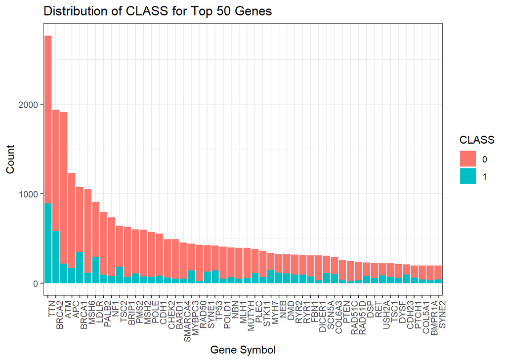

## Encoding and Engineering Features

Features will be encoded and engineered based on discussion during EDA, starting with low cardinality features then progressing to high cardinality.

### Encoding Low Cardinality Data

First, dummy encoding of features.

```r
binary.func <- function(df) {
  # encode based on EDA
  df$ORIGIN <- ifelse(df$ORIGIN == 1, 0, 1)
  df$IMPACT <- ifelse(df$IMPACT == "HIGH", 1, 0)
  df$POS_STRAND <- ifelse(df$STRAND == 1, 1, 0)

  return(df)
}
```

A function was written to encode Origin, Impact and Strand for any given dataframe.

```
## 'data.frame':    65174 obs. of  3 variables:
##  $ ORIGIN    : num  0 0 1 1 1 1 0 0 0 0 ...
##  $ IMPACT    : num  0 0 0 0 0 0 0 0 0 0 ...
##  $ POS_STRAND: num  1 0 0 1 1 1 1 1 1 0 ...
```

The features are now encoded and ready for modeling.

A function to create new features with the lengths of nucleotides and generate a feature indicating if a variant is single nucleotide in nature or not.

```
## 'data.frame':    65174 obs. of  4 variables:
##  $ REF_length   : int  1 1 1 1 1 1 1 1 1 1 ...
##  $ ALT_length   : int  1 1 1 1 1 1 1 1 1 1 ...
##  $ Allele_length: int  1 1 1 1 1 1 1 1 1 1 ...
##  $ SNV          : num  1 1 1 1 1 1 1 1 1 1 ...
```

The table shows the new length features and the SNV feature.

The features are now engineered, encoded and ready for modeling.

### Encoding High Cardinality Data

Consequence and MC have mostly matching names once the character strings are split. A function was written to handle the heavy lifting.

Now comes the implementation, several comes will be combined based on biological context to reduce noise, or because they have only a few positive classes. For example upstream variants and 500 byte upstream variants were combined to reduce dimensionality and noise.

```
## 'data.frame':    65174 obs. of  16 variables:
##  $ SNV                    : num  1 1 1 1 1 1 1 1 1 1 ...
##  $ nonsense               : num  0 0 0 0 0 0 0 0 0 0 ...
##  $ splice_region_variant  : num  0 0 0 0 0 0 0 0 0 0 ...
##  $ downstream_gene_variant: num  0 0 0 0 0 0 0 0 0 0 ...
##  $ upstream_gene_variant  : num  0 0 0 0 0 0 0 0 0 0 ...
##  $ inframe_deletion       : num  0 0 0 0 0 0 0 0 0 0 ...
##  $ inframe_insertion      : num  0 0 0 0 0 0 0 0 0 0 ...
##  $ stop_gained            : num  0 0 0 0 0 0 0 0 0 0 ...
##  $ start_lost             : num  0 0 0 0 0 0 0 0 0 0 ...
##  $ Cons.OTHER             : int  0 0 0 0 0 0 0 0 0 0 ...
##  $ missense_variant       : num  1 1 1 1 1 1 1 1 1 1 ...
##  $ X5_prime_UTR_variant   : num  0 0 1 0 0 0 0 0 0 0 ...
##  $ intron_variant         : num  0 0 0 0 0 0 0 0 0 0 ...
##  $ X3_prime_UTR_variant   : num  0 0 0 0 0 0 0 0 0 0 ...
##  $ synonymous_variant     : num  0 0 0 0 0 0 0 0 0 0 ...
##  $ frameshift_variant     : num  0 0 0 0 0 0 0 0 0 0 ...
```

The data from MC and Consequence is now expanded into ML readable format and optimized.

Two steps were taken to encode the remaining High-cardinality data, first low-frequency categories were be binned into a “low.freq” group to reduce noise, then those updated features were encoded using weight of evidence.

```
## 'data.frame':    65174 obs. of  10 variables:
##  $ CLNDN           : Factor w/ 26 levels "1494","2646",..: 26 25 25 25 25 25 26 26 25 25 ...
##  $ SYMBOL          : Factor w/ 47 levels "APC","ATM","BARD1",..: 17 17 17 17 17 17 17 17 17 17 ...
##  $ EXON            : Factor w/ 44 levels "1/1","1/10","1/3",..: 1 29 43 43 43 43 43 43 43 43 ...
##  $ cDNA_position   : Factor w/ 2 levels "low.freq","non_coding": 1 1 1 1 1 1 1 1 1 1 ...
##  $ Amino_acids     : Factor w/ 72 levels "A","A/S","A/T",..: 12 42 26 21 35 20 35 42 70 64 ...
##  $ Codons          : Factor w/ 72 levels "aaC/aaT","aaG/aaA",..: 63 26 63 55 63 63 63 63 60 7 ...
##  $ CLNDISDB        : Factor w/ 27 levels "Human_Phenotype_Ontology:HP:0001639,MedGen:C0007194,Orphanet:ORPHA217569|MedGen:CN169374",..: 25 3 3 3 3 3 25 25 3 3 ...
##  $ Feature         : Factor w/ 47 levels "low.freq","NM_000051.3",..: 1 1 1 1 1 1 1 1 1 1 ...
##  $ CDS_position    : Factor w/ 2 levels "low.freq","non_coding": 1 1 1 1 1 1 1 1 1 1 ...
##  $ Protein_position: Factor w/ 2 levels "low.freq","non_coding": 1 1 1 1 1 1 1 1 1 1 ...
```

Note the greatly reduced number of factor levels post binning.

The final step in the encoding process is weight of evidence encoding, this was performed after the data is split into validation and training sets to prevent data leakage. A function to handle the process was prepared here. Note that a very small laplace smoothing factor was introduced due to sparsity of some categories, even after binning.

## Prepare Data for modeling:

### Prepare: Split Data

First a standard 80/20 holdout split will be performed.

```r
set.seed(42) # Answer to Universe life and everything in between

# get index
trnindx <- createDataPartition(df.sep$CLASS, p = 0.8, list = FALSE)

df.train <- df.sep[trnindx,]

# test
df.test <- df.sep[-trnindx,]
```

### Prepare: Woe Encoding

Features will be weight of evidence encoded, the table below shows the results of the transformation.

|  | CLNDN | SYMBOL | EXON | CHROM | cDNA_position | Amino_acids | Codons | PolyPhen | BLOSUM62 | CLNVC | SIFT | CLNDISDB | Feature | CDS_position | Protein_position |
| --- | --- | --- | --- | --- | --- | --- | --- | --- | --- | --- | --- | --- | --- | --- | --- |
| 1 | -0.035 | 0.119 | 0.356 | 0.114 | -0.008 | 0.009 | -0.131 | 0.048 | -0.041 | 0.02 | 0.068 | -0.215 | 0.119 | -0.021 | -0.021 |
| 2 | 0.163 | 0.119 | -0.011 | 0.114 | -0.008 | 0.128 | 0.195 | 0.048 | 0.143 | 0.02 | 0.079 | 0.163 | 0.119 | -0.021 | -0.021 |
| 5 | 0.163 | 0.119 | 0.042 | 0.114 | -0.008 | -0.256 | -0.131 | -0.037 | 0.143 | 0.02 | -0.039 | 0.163 | 0.119 | -0.021 | -0.021 |
| 6 | 0.163 | 0.119 | 0.042 | 0.114 | -0.008 | 0.045 | -0.131 | -0.037 | 0.006 | 0.02 | -0.039 | 0.163 | 0.119 | -0.021 | -0.021 |
| 7 | -0.035 | 0.119 | 0.042 | 0.114 | -0.008 | -0.256 | -0.131 | -0.037 | 0.002 | 0.02 | -0.039 | -0.215 | 0.119 | -0.021 | -0.021 |
| 8 | -0.035 | 0.119 | 0.042 | 0.114 | -0.008 | 0.128 | -0.131 | -0.037 | 0.143 | 0.02 | -0.039 | -0.215 | 0.119 | -0.021 | -0.021 |

Features have now been encoded with WOE encoding, final step is correcting class imbalance.

### Prepare: Correct Class Imbalance

Due to the class imbalance discovered during EDA, the training data will undergo a resampling method combining upsampling and downsampling discussed [here](https://machinelearningmastery.com/combine-oversampling-and-undersampling-for-imbalanced-classification/)

```
##
##     0     1
## 39000 39000
```

The class imbalance has now been addressed.

### Prepare: Log Regression Data

For comparison a set of data was prepared for the logreg model that controls for collinearity, transforms relevant data to a normal distribution and scales. This step was wrapped in a function to simplify the process.

```r
normalize.it<- function(df){
  # remove colinear variables from EDA
  df.colin <- df[, !names(df) %in% colin.vars]

  # apply square root transform on CADD_PHREDD
  df.colin$CADD_PHRED <- sqrt(df.colin$CADD_PHRED)

  # vector of features to scale
  to.scale <- c("AF_TGP", "CDS_position", "CADD_PHRED", "REF_length", "ALT_length"
                , "Allele_length")
  #standardize features using scale
  scaled.feat <- scale(df.colin[, names(df.colin) %in% to.scale])

  # assign to dataframe
  df.scale <- df.colin
  df.scale[,to.scale] <- scaled.feat

  df.scale$CLASS <- as.numeric(as.character(df.scale$CLASS))

  return(df.scale)
}
```

### Prepare: Feature Selection

Chi-Square, ANOVA, and PCA will be conducted. Chi-Square for all encoded features, ANOVA analysis for all continuous features, PCA will be used to get an idea of how the WOE encoded features are playing a role.

PCA will be performed to get an idea of the constituent components.

Final features for modeling will be selected based on p-value threshold.

#### Prepare: Chi Square Analysis

```
##                        Feature        pvalue chisq.stat
## X-squared1              IMPACT  0.000000e+00  1733.3498
## X-squared19              CLASS  0.000000e+00 77996.0001
## X-squared10        stop_gained 6.436431e-160   726.0613
## X-squared4            nonsense 9.452891e-157   711.4973
## X-squared18 frameshift_variant 5.779048e-146   661.8967
## X-squared3                 SNV  1.892663e-27   117.8262
```

From the table it can be seen that several of the engineered features hold predictive value based on P values and Chi Square statistic.

There are 0 features that are not significant. Chi Square analysis suggests all catregorical features are statistically significant.

#### Prepare: ANOVA Analysis

```
##      Feature       pvalue
## 1     AF_ESP 0.000000e+00
## 2    AF_EXAC 0.000000e+00
## 3     AF_TGP 0.000000e+00
## 6   CADD_RAW 2.766497e-70
## 5 CADD_PHRED 2.208546e-43
## 4    LoFtool 5.195298e-02
```

#### Prepare: Principle Component Analysis

PCA was performed to identify features responsible for variance within the datset. Some of the techniques found [here](https://www.r-bloggers.com/2021/05/principal-component-analysis-pca-in-r/) were incorporated into the analysis.

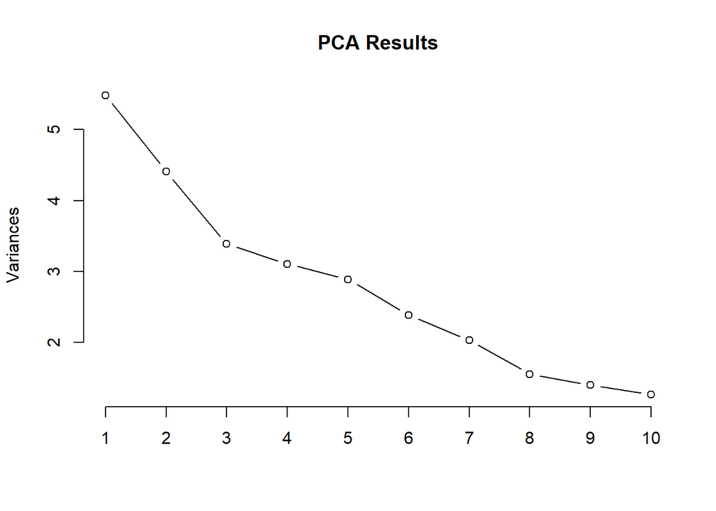

From the elbow plot we see that most variance can be explained by the first 8 or 9 principle components. The table below shows some of the features contributing to the first five principle components.

```
##                     PC1    PC2    PC3    PC4    PC5
## CHROM            -0.019 -0.036  0.165 -0.024  0.014
## AF_ESP           -0.086 -0.070  0.126  0.175  0.028
## AF_EXAC          -0.081 -0.067  0.124  0.168  0.027
## AF_TGP           -0.089 -0.070  0.124  0.173  0.026
## CLNDISDB         -0.046 -0.066  0.434 -0.044  0.023
## CLNDN            -0.052 -0.067  0.437 -0.039  0.025
## CLNVC             0.072 -0.268 -0.012  0.229 -0.294
## ORIGIN            0.051  0.038  0.058 -0.054 -0.031
## IMPACT            0.036  0.386  0.077 -0.012 -0.083
## SYMBOL           -0.047 -0.096  0.456 -0.046  0.029
## Feature          -0.047 -0.096  0.456 -0.046  0.029
## EXON             -0.071 -0.034  0.213 -0.039 -0.013
## cDNA_position    -0.331  0.035 -0.032 -0.195 -0.251
## CDS_position     -0.342  0.033 -0.031 -0.192 -0.243
## Protein_position -0.342  0.033 -0.031 -0.192 -0.243
## Amino_acids      -0.121 -0.310 -0.077 -0.173  0.110
## Codons           -0.121 -0.268 -0.061 -0.190  0.122
## SIFT              0.282 -0.153 -0.015 -0.223 -0.087
## PolyPhen          0.291 -0.154 -0.011 -0.229 -0.091
## LoFtool          -0.014  0.013 -0.051  0.052  0.021
```

It appears that the WOE encoded variables do meaningfully represent the variance of the dataset based on the weights for various positions in PC1 and Clinical diagnoses in PC3.

## BUILD: MODELS

Three models will be created, a boosted decision tree, a random forest model, and a logistic regression with an elastic net.

the tree based models are highly resistant to noisy data found in this dataset and well suited to capturing nonlinear patterns, the enhanced logistic regression model provides interpretability, and will balance the tree models tendency to over fit the data with the regularization provided by the elastic net.

### BUILD: Base models

Base models were constructed one boosted tree, a random forest, and a logistic regression model with elastic net.

```r
# Tree
model.x <- xgboost(data=xgb.matrix, label = xgb.label, nrounds=100,
                   objective = "binary:logistic", verbose = 0) # silence printout

# random forest
model3.s  <- ranger(CLASS ~ ., data = df.down, probability = TRUE)
# logreg model
model.g <- glmnet(xgb.matrix, y=xgb.label, family = binomial, standardize = TRUE)

#normalized logreg model
model.n <- glmnet(as.matrix(normalize.it(df.down)), y=xgb.label,
                  family = binomial, standardize = FALSE)
```

### BUILD: Base Model Predictions

The boosted decision tree and random forest model predictions are shown below.

```
## Confusion Matrix and Statistics
##
##           Reference
## Prediction    0    1
##          0 6866  866
##          1 2883 2419
##
##                Accuracy : 0.7124
##                  95% CI : (0.7045, 0.7201)
##     No Information Rate : 0.748
##     P-Value [Acc > NIR] : 1
##
##                   Kappa : 0.3661
##
##  Mcnemar's Test P-Value : <2e-16
##
##             Sensitivity : 0.7364
##             Specificity : 0.7043
##          Pos Pred Value : 0.4562
##          Neg Pred Value : 0.8880
##              Prevalence : 0.2520
##          Detection Rate : 0.1856
##    Detection Prevalence : 0.4068
##       Balanced Accuracy : 0.7203
##
##        'Positive' Class : 1
##
```

The boosted tree shows reasonable sensitivity and specificity, with some concern for its weak positive predictive value or precision.

The random forest model output is shown below.

```
## Confusion Matrix and Statistics
##
##           Reference
## Prediction    0    1
##          0 7887 1280
##          1 1862 2005
##
##                Accuracy : 0.7589
##                  95% CI : (0.7515, 0.7663)
##     No Information Rate : 0.748
##     P-Value [Acc > NIR] : 0.001943
##
##                   Kappa : 0.3961
##
##  Mcnemar's Test P-Value : < 2.2e-16
##
##             Sensitivity : 0.6104
##             Specificity : 0.8090
##          Pos Pred Value : 0.5185
##          Neg Pred Value : 0.8604
##              Prevalence : 0.2520
##          Detection Rate : 0.1538
##    Detection Prevalence : 0.2967
##       Balanced Accuracy : 0.7097
##
##        'Positive' Class : 1
##
```

Now a comparison of the logistic regression models with and without handling of collinearity.

```
## Confusion Matrix and Statistics
##
##           Reference
## Prediction    0    1
##          0 4516  443
##          1 5233 2842
##
##                Accuracy : 0.5645
##                  95% CI : (0.556, 0.5731)
##     No Information Rate : 0.748
##     P-Value [Acc > NIR] : 1
##
##                   Kappa : 0.2214
##
##  Mcnemar's Test P-Value : <2e-16
##
##             Sensitivity : 0.8651
##             Specificity : 0.4632
##          Pos Pred Value : 0.3520
##          Neg Pred Value : 0.9107
##              Prevalence : 0.2520
##          Detection Rate : 0.2180
##    Detection Prevalence : 0.6195
##       Balanced Accuracy : 0.6642
##
##        'Positive' Class : 1
##
```

```
## Confusion Matrix and Statistics
##
##           Reference
## Prediction    0    1
##          0 9348 3262
##          1  401   23
##
##                Accuracy : 0.719
##                  95% CI : (0.7112, 0.7267)
##     No Information Rate : 0.748
##     P-Value [Acc > NIR] : 1
##
##                   Kappa : -0.048
##
##  Mcnemar's Test P-Value : <2e-16
##
##             Sensitivity : 0.007002
##             Specificity : 0.958868
##          Pos Pred Value : 0.054245
##          Neg Pred Value : 0.741316
##              Prevalence : 0.252033
##          Detection Rate : 0.001765
##    Detection Prevalence : 0.032530
##       Balanced Accuracy : 0.482935
##
##        'Positive' Class : 1
##
```

The tree and forest models have similar accuracy scores, interestingly the Tree model is more sensitive while the ranger model has high specificity. Indicating they complement each other well.

The logistic regression model underperformed in terms of *overall* accuracy compared to the tree based models, but had the highest sensitivity of all of them and its balanced accuracy was not unreasonably far behind.This was at the cost of a large number of false positives.Note the poor performance of the logreg model with transformations, normalization and collinear features removed. likely the signal each feature was contributing was weak on it’s own and removal made the signal imperceptible.

F1 scores will be calculated to determine each models efficacy at identifying conflicting variants.

### BUILD: F1 score for Base Models

An F1 function was defined and the F1 scores calculated for each model.

| Tree | 0.5634098 |
| --- | --- |
| Forest | 0.5606823 |
| Log.Reg | 0.5003521 |

The Tree model has the highest F1 score, and the log regression has the lowest. From a general standpoint they are on the low side, however inth e context of the dataset they are respectable.

### BUILD: ROC Base models

ROC curve for each of the models was calculated with optimal specificity and sensitivity thresholds using Youden’s J statistic.

```
##   threshold specificity sensitivity
## 1 0.4961412   0.7012001   0.7415525
## 2 0.3776225   0.6660170   0.7936073
## 3 0.5227780   0.5101036   0.8277017
```

Interestingly the default choice of 0.5 for a threshold was fairly close for the decision tree and log reg model. The Random forest required a much lower value to optimize sensitivity and specificity.

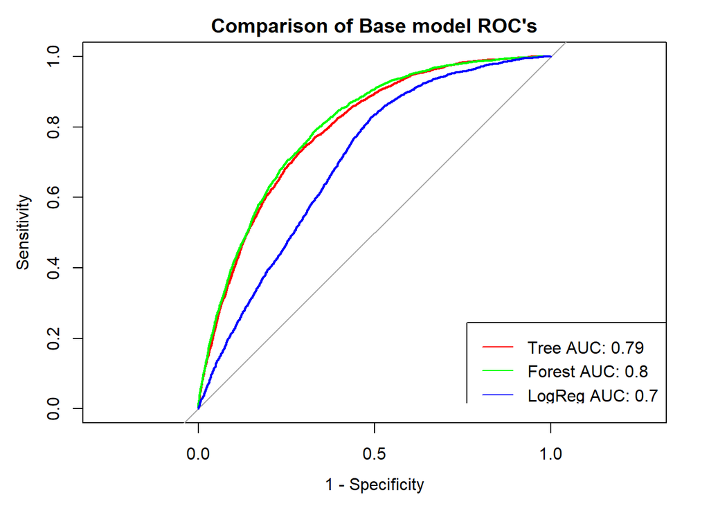

These values are poor due to the noise of the dataset. When placed in the context of other modeling attempts on this dataset they are on the higher end.

Further improvements will be made by constructing a stacked ensemble model.

## Evaluation and Tuning

The data is split again for future training of the stacked model, and K fold validation and bagging is set up.

### EVAL: Holdout data for training

A second split of data was performed to prevent data leakage when training the stacked model. This was again done as an 80/20 split.

```r
# ensure reproducibility
set.seed(42)

meta.trn <-createDataPartition(df.woe$CLASS, p = 0.8, list = FALSE)

meta.train <- df.woe[meta.trn,]
meta.test <- df.woe[-meta.trn,]
```

### EVAL: Up Down Sampling for Bagged Models

To prevent data leakage our bagged models needs to be up and down sampled during the k-fold step. This was specified in Caret using a custom function. An explanation of this technique is found [here](https://topepo.github.io/caret/subsampling-for-class-imbalances.html#using-custom-subsampling-techniques)

### EVAL: Bootstrapping bagged models

```r
# ensure reproducibility
set.seed(42)

# Use different random seeds for each trial
seeds <- vector(mode = "list", length = 51)
for(i in 1:50) seeds[[i]] <- sample.int(1000, 50)

## For the last model:
seeds[[51]] <- sample.int(1000, 1)


# 5 fold cross validation best model predictions saved for training stacked model
trnctrl <- trainControl(method = "cv", number = 5, savePredictions = "final",
                        classProbs = TRUE, seeds = seeds, verboseIter = FALSE,
                        summaryFunction = prSummary, sampling = updown)
```

The above allows us to establish a random seed for each step of k-fold validation and bagged dataset. Bagging was combined with downsampling within a function to train each model. prSummary was chosen as the summary function to allow training of the model using F1 score.

The holdout data was bootstrapped into 9 distinct datasets for training of homogenous bagged ensemble learners.

### EVAL: Ensemble Base Learners

The bagged data was used to train three base learners for a homogeneous ensemble. Three base learners per ensemble was chosen due to time and memory constraints. A wide range of hyperparameters were experimented with. Out of respect for the reader’s time and memory constraints only a few are shown.

Hyperparameters explored for the tree and forest models included boosting rounds, max tree depth, features per split (mtry) and node size.

For the logistic regression model a wide range of alpha and lambda parameters were explored. The best results were found with a relatively weak lambda and a smaller alpha value lending more weight to the Ridge regularization aspect of the elastic net.

```r
tree.models <- list()

# establish grid with variables to try (reduced in size for time)
xgb.grid <- expand.grid(
  nrounds = c(150,200), # boosting rounds limited to 200  c(100,200,300,500)
  max_depth = c(2,3), # shallow depth trees prevent overfitting c(2,3,5,7,10)
  eta = c(0.4), # default learning rate c(0.3,0.4,0.5)
  gamma = 0, # default
  colsample_bytree = c(0.8,1), # proportion of features used in a  tree
  min_child_weight = c(1),  # default
  subsample = c(0.75, 1)  # proportion of training data per tree
)


for (i in seq_along(tree.bags)) {
# Decision Tree, boosted
tree.final <- train(
  CLASS ~.,
  data = tree.bags[[i]],
  method = "xgbTree",
  trControl = trnctrl,
  tuneGrid = xgb.grid,
  metric = "F",
  verbosity = 0
)
tree.models[[i]] <- tree.final
}
names(tree.models) <-paste0("tree.model_", 1:3)
```

```
## Confusion Matrix and Statistics
##
##           Reference
## Prediction   X0   X1
##         X0 5299  734
##         X1 2501 1894
##
##                Accuracy : 0.6898
##                  95% CI : (0.6808, 0.6986)
##     No Information Rate : 0.748
##     P-Value [Acc > NIR] : 1
##
##                   Kappa : 0.3271
##
##  Mcnemar's Test P-Value : <2e-16
##
##             Sensitivity : 0.7207
##             Specificity : 0.6794
##          Pos Pred Value : 0.4309
##          Neg Pred Value : 0.8783
##              Prevalence : 0.2520
##          Detection Rate : 0.1816
##    Detection Prevalence : 0.4215
##       Balanced Accuracy : 0.7000
##
##        'Positive' Class : X1
##
## Confusion Matrix and Statistics
##
##           Reference
## Prediction   X0   X1
##         X0 5407  739
##         X1 2393 1889
##
##                Accuracy : 0.6997
##                  95% CI : (0.6908, 0.7084)
##     No Information Rate : 0.748
##     P-Value [Acc > NIR] : 1
##
##                   Kappa : 0.3409
```

[output cut: 26 more lines]

```
##                   Kappa : 0.3296
##
##  Mcnemar's Test P-Value : <2e-16
##
##             Sensitivity : 0.7131
##             Specificity : 0.6868
##          Pos Pred Value : 0.4341
##          Neg Pred Value : 0.8766
##              Prevalence : 0.2520
##          Detection Rate : 0.1797
##    Detection Prevalence : 0.4140
##       Balanced Accuracy : 0.6999
##
##        'Positive' Class : X1
##
```

All of the tree models share similar statistics, with some slight variation, notably they have strong sensitivity.

```r
forest.models <- list()

# establish grid with variables to try
rf.grid <- expand.grid(
  mtry = c(6), # minimum number of features per split c(4,5,6,7)
  splitrule = c("gini"), # gini impurity
  min.node.size = c(3,5) # minimum observations per tree c(3,4,5,6)
)

# Random forest
for (i in seq_along(forest.bags)) {
forest.final <- train(
  CLASS ~.,
  data = forest.bags[[i]],
  method = "ranger",
  trControl = trnctrl,
  tuneGrid = rf.grid,
  metric = "F",
  verbose = FALSE
)
forest.models[[i]] <- forest.final
}
names(forest.models) <-paste0("forest.model_", 1:3)
```

```
## Confusion Matrix and Statistics
##
##           Reference
## Prediction   X0   X1
##         X0 6532 1333
##         X1 1268 1295
##
##                Accuracy : 0.7506
##                  95% CI : (0.7422, 0.7589)
##     No Information Rate : 0.748
##     P-Value [Acc > NIR] : 0.2754
##
##                   Kappa : 0.3329
##
##  Mcnemar's Test P-Value : 0.2095
##
##             Sensitivity : 0.4928
##             Specificity : 0.8374
##          Pos Pred Value : 0.5053
##          Neg Pred Value : 0.8305
##              Prevalence : 0.2520
##          Detection Rate : 0.1242
##    Detection Prevalence : 0.2458
##       Balanced Accuracy : 0.6651
##
##        'Positive' Class : X1
##
## Confusion Matrix and Statistics
##
##           Reference
## Prediction   X0   X1
##         X0 6569 1357
##         X1 1231 1271
##
##                Accuracy : 0.7518
##                  95% CI : (0.7434, 0.7601)
##     No Information Rate : 0.748
##     P-Value [Acc > NIR] : 0.18659
##
##                   Kappa : 0.3311
```

[output cut: 26 more lines]

```
##                   Kappa : 0.3556
##
##  Mcnemar's Test P-Value : 0.38066
##
##             Sensitivity : 0.5122
##             Specificity : 0.8414
##          Pos Pred Value : 0.5211
##          Neg Pred Value : 0.8366
##              Prevalence : 0.2520
##          Detection Rate : 0.1291
##    Detection Prevalence : 0.2477
##       Balanced Accuracy : 0.6768
##
##        'Positive' Class : X1
##
```

The forest models share similar distributions, but their specificity is much higher than their sensitivity.

```r
logreg.models <- list()

# establish grid with variables to try
logreg.grid <- expand.grid(
  alpha = c(0.1, 0.2),  # controls blend of lasso and ridge
  lambda = c(0.0002,0.00025, 0.0003)  # regularization strength
)

for (i in seq_along(logreg.bags)) {
# Decision Tree, boosted
logreg.final <- train(
  CLASS ~.,
  data = logreg.bags[[i]],
  method = "glmnet",
  trControl = trnctrl,
  tuneGrid = logreg.grid,
  metric = "F",
  verbose = FALSE
)
logreg.models[[i]] <- logreg.final
}
names(logreg.models) <-paste0("logreg.model_", 1:3)
```

```
## Confusion Matrix and Statistics
##
##           Reference
## Prediction   X0   X1
##         X0 3670  386
##         X1 4130 2242
##
##                Accuracy : 0.5669
##                  95% CI : (0.5574, 0.5765)
##     No Information Rate : 0.748
##     P-Value [Acc > NIR] : 1
##
##                   Kappa : 0.2198
##
##  Mcnemar's Test P-Value : <2e-16
##
##             Sensitivity : 0.8531
##             Specificity : 0.4705
##          Pos Pred Value : 0.3519
##          Neg Pred Value : 0.9048
##              Prevalence : 0.2520
##          Detection Rate : 0.2150
##    Detection Prevalence : 0.6110
##       Balanced Accuracy : 0.6618
##
##        'Positive' Class : X1
##
## Confusion Matrix and Statistics
##
##           Reference
## Prediction   X0   X1
##         X0 3660  364
##         X1 4140 2264
##
##                Accuracy : 0.5681
##                  95% CI : (0.5585, 0.5776)
##     No Information Rate : 0.748
##     P-Value [Acc > NIR] : 1
##
##                   Kappa : 0.224
```

[output cut: 26 more lines]

```
##                   Kappa : 0.222
##
##  Mcnemar's Test P-Value : <2e-16
##
##             Sensitivity : 0.8554
##             Specificity : 0.4714
##          Pos Pred Value : 0.3528
##          Neg Pred Value : 0.9063
##              Prevalence : 0.2520
##          Detection Rate : 0.2156
##    Detection Prevalence : 0.6110
##       Balanced Accuracy : 0.6634
##
##        'Positive' Class : X1
##
```

The logistic regression model does not perform as well as the tree based models, it strongly overestimates the positive class.

### EVAL: Ensemble Combine

Each set of the three models will be combined into a soft vote homogeneous ensemble learner wherein the mean of the three base learners are averaged and returned as the prediction. A generalized function was implemented for this purpose.

```r
Ensemble.model <- function(model.list, test.data) {

  # initialize list for preds with correct dims
  predictions <- data.frame(matrix(ncol = length(model.list),
                                   nrow=nrow(test.data)))
  # get predictions
  for (i in seq_along(model.list)) {
    # get initial predictions
    pred <- predict(model.list[[i]], test.data, type = "prob")[, "X1"]
    predictions[[i]] <- pred
  }
  # distinguish
  names(predictions) <- paste0("model_", seq_along(model.list))

 # Take the mean probability per row (i.e., across models)
  avg.preds <- rowMeans(predictions)


  # Final prediction based on averaged prob and threshold
  final.pred <- ifelse(avg.preds > 0.5, "X1", "X0")

  return(factor(final.pred, levels = c("X0", "X1")))
}
```

First the Tree ensemble will be examined.

```
## Confusion Matrix and Statistics
##
##           Reference
## Prediction   X0   X1
##         X0 5409  726
##         X1 2391 1902
##
##                Accuracy : 0.7011
##                  95% CI : (0.6922, 0.7099)
##     No Information Rate : 0.748
##     P-Value [Acc > NIR] : 1
##
##                   Kappa : 0.3448
##
##  Mcnemar's Test P-Value : <2e-16
##
##             Sensitivity : 0.7237
##             Specificity : 0.6935
##          Pos Pred Value : 0.4430
##          Neg Pred Value : 0.8817
##              Prevalence : 0.2520
##          Detection Rate : 0.1824
##    Detection Prevalence : 0.4117
##       Balanced Accuracy : 0.7086
##
##        'Positive' Class : X1
##
```

The homogeneous ensemble learner outperforms its base models, offering better stats overall.

Now the random Forest model.

```
## Confusion Matrix and Statistics
##
##           Reference
## Prediction   X0   X1
##         X0 6581 1327
##         X1 1219 1301
##
##                Accuracy : 0.7558
##                  95% CI : (0.7475, 0.7641)
##     No Information Rate : 0.748
##     P-Value [Acc > NIR] : 0.03268
##
##                   Kappa : 0.3435
##
##  Mcnemar's Test P-Value : 0.03396
##
##             Sensitivity : 0.4951
##             Specificity : 0.8437
##          Pos Pred Value : 0.5163
##          Neg Pred Value : 0.8322
##              Prevalence : 0.2520
##          Detection Rate : 0.1248
##    Detection Prevalence : 0.2417
##       Balanced Accuracy : 0.6694
##
##        'Positive' Class : X1
##
```

A similar sentiment is shared by the homogeneous forest model.

Finally the logistic regression model.

```
## Confusion Matrix and Statistics
##
##           Reference
## Prediction   X0   X1
##         X0 3661  367
##         X1 4139 2261
##
##                Accuracy : 0.5679
##                  95% CI : (0.5583, 0.5774)
##     No Information Rate : 0.748
##     P-Value [Acc > NIR] : 1
##
##                   Kappa : 0.2234
##
##  Mcnemar's Test P-Value : <2e-16
##
##             Sensitivity : 0.8604
##             Specificity : 0.4694
##          Pos Pred Value : 0.3533
##          Neg Pred Value : 0.9089
##              Prevalence : 0.2520
##          Detection Rate : 0.2168
##    Detection Prevalence : 0.6137
##       Balanced Accuracy : 0.6649
##
##        'Positive' Class : X1
##
```

Again the logreg model seems to have less variance than its base models.

All three models show improvement in line with the Condorcet Jury Theorem.

### EVAL: Stacked Model

A meta learner in the form of a boosted tree will make the final decision based on the model predictions, a boosted decision tree model was used as the meta learner. The choice is based on the need to compensate for sub-model variation and bias.

First a test data set was prepared for the meta learner by combining predictions on the validation set with the true labels.

Then training parameters for the stacked model were defined with 5 fold validation, repeating use of F1 statistic as the training metric.

A function that passes the training data and the models was written. The models are passed to the ensemble model function and their predictions stored in a dataframe with the true labels. This functions as the training set for the meta model, which was tuned using a wide range of hyperparameters.

Now the model will be called and predictions made with the best threshold decided by using the ROC method shown earlier. The decision to use ROC threshold as a final balancing metric over F1 statistic was implemented to fully round out the model after baking F1 performance into the sub model’s predictions.

```
## Confusion Matrix and Statistics
##
##           Reference
## Prediction    0    1
##          0 6716  800
##          1 3033 2485
##
##                Accuracy : 0.7059
##                  95% CI : (0.698, 0.7137)
##     No Information Rate : 0.748
##     P-Value [Acc > NIR] : 1
##
##                   Kappa : 0.3635
##
##  Mcnemar's Test P-Value : <2e-16
##
##             Sensitivity : 0.7565
##             Specificity : 0.6889
##          Pos Pred Value : 0.4503
##          Neg Pred Value : 0.8936
##              Prevalence : 0.2520
##          Detection Rate : 0.1907
##    Detection Prevalence : 0.4234
##       Balanced Accuracy : 0.7227
##
##        'Positive' Class : 1
##
```

The stacked model has the highest balanced accuracy of all models, and an excellent sensitivity compared to the rest. Given the projects primary goal of helping researchers identify variants with conflicting status this is an acceptable trade-off.

| Tree | 0.56 |
| --- | --- |
| Forest | 0.56 |
| Log.Reg | 0.50 |
| MetaModel | 0.56 |

By F1 score alone the model only slightly out performs the other models. When the balanced accuracy, and general robustness of the model is considered it gains significant ground in terms of quality.

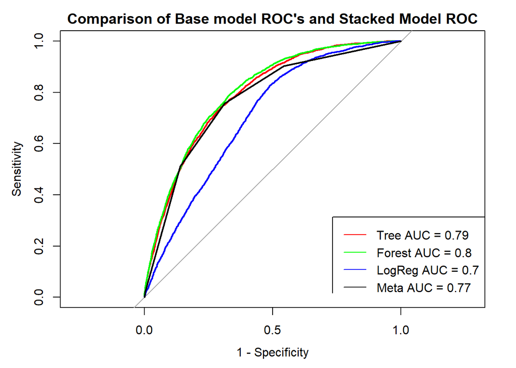

From the ROC-AUC comparison to the base learners, we can see that it generally performs on par with the tree based models, though the glmnet seems to drag its overall performance down some.

## Conclusion

The stacked model is the most robust model for detecting conflicting sentiment towards a variant in the ClinVar database. It provides a comparable F1 score to sub models, and better balanced accuracy. Most importantly, it accomplishes this *without* any of the tradeoffs the base models suffered from regarding sensitivity and specificity.

|  | F1 | Sensitivity | Specificity | Balanced Accuracy |
| --- | --- | --- | --- | --- |
| Meta Model | 0.56 | 0.76 | 0.69 | 0.72 |
| Tree Model | 0.56 | 0.74 | 0.70 | 0.72 |
| Forest Model | 0.56 | 0.61 | 0.81 | 0.71 |
| Logistic Reg. | 0.50 | 0.87 | 0.46 | 0.66 |

Though the reported F1 score of 0.5645803 and other statistics may be considered poor in a general sense, when considered in the context of the data, and compared to previous work done the model is a top contender.

While the model is not entirely suitable for clinical researchers or medical applications,it can serve as a tool for researchers during the discovery phase of a new project, or in conjunction with other methods.

Suggested future improvements include removing or replacing the glmnet model in the stack with something more robust. More robust feature engineering such as annotating transitions and transversions, identifying amino acid changes that result in major structural changes relative to the original such as alanine to phenylalanine.